# PROJECT: FLIGHT PRICE PREDICTION

```python
#Importing the libreris like pandas, numpy for selecing the data and convering the data to dataframe as shown below
import pandas as pd
import numpy as np
import warnings
warnings.filterwarnings('ignore')
```

```python
#Creating the variable train_df and loading the dataset  to the variable train_df
train_df=pd.read_excel('flightprice.xlsx')
train_df
```

|  | Airline | Date_of_Journey | Source | Destination | Route | Dep_Time | Arrival_Time | Duration | Total_Stops | Additional_Info | Price |
| --- | --- | --- | --- | --- | --- | --- | --- | --- | --- | --- | --- |
| 0 | IndiGo | 24/03/2019 | Banglore | New Delhi | BLR → DEL | 22:20 | 01:10 22 Mar | 2h 50m | non-stop | No info | 3897 |
| 1 | Air India | 1/05/2019 | Kolkata | Banglore | CCU → IXR → BBI → BLR | 05:50 | 13:15 | 7h 25m | 2 stops | No info | 7662 |
| 2 | Jet Airways | 9/06/2019 | Delhi | Cochin | DEL → LKO → BOM → COK | 09:25 | 04:25 10 Jun | 19h | 2 stops | No info | 13882 |
| 3 | IndiGo | 12/05/2019 | Kolkata | Banglore | CCU → NAG → BLR | 18:05 | 23:30 | 5h 25m | 1 stop | No info | 6218 |
| 4 | IndiGo | 01/03/2019 | Banglore | New Delhi | BLR → NAG → DEL | 16:50 | 21:35 | 4h 45m | 1 stop | No info | 13302 |
| ... | ... | ... | ... | ... | ... | ... | ... | ... | ... | ... | ... |
| 10678 | Air Asia | 9/04/2019 | Kolkata | Banglore | CCU → BLR | 19:55 | 22:25 | 2h 30m | non-stop | No info | 4107 |
| 10679 | Air India | 27/04/2019 | Kolkata | Banglore | CCU → BLR | 20:45 | 23:20 | 2h 35m | non-stop | No info | 4145 |
| 10680 | Jet Airways | 27/04/2019 | Banglore | Delhi | BLR → DEL | 08:20 | 11:20 | 3h | non-stop | No info | 7229 |
| 10681 | Vistara | 01/03/2019 | Banglore | New Delhi | BLR → DEL | 11:30 | 14:10 | 2h 40m | non-stop | No info | 12648 |
| 10682 | Air India | 9/05/2019 | Delhi | Cochin | DEL → GOI → BOM → COK | 10:55 | 19:15 | 8h 20m | 2 stops | No info | 11753 |

10683 rows × 11 columns

```python
train_df.info()
```

```
<class 'pandas.core.frame.DataFrame'>
RangeIndex: 10683 entries, 0 to 10682
Data columns (total 11 columns):
 #   Column           Non-Null Count  Dtype
---  ------           --------------  -----
 0   Airline          10683 non-null  object
 1   Date_of_Journey  10683 non-null  object
 2   Source           10683 non-null  object
 3   Destination      10683 non-null  object
 4   Route            10682 non-null  object
 5   Dep_Time         10683 non-null  object
 6   Arrival_Time     10683 non-null  object
 7   Duration         10683 non-null  object
 8   Total_Stops      10682 non-null  object
 9   Additional_Info  10683 non-null  object
 10  Price            10683 non-null  int64
dtypes: int64(1), object(10)
memory usage: 918.2+ KB
```

```python
#checking the shape of the train_df dataset shape
train_df.shape
```

```
(10683, 11)
```

train_df having the shape 10683 rows 11 columns

```python
# checking for null values
train_df.isnull().sum()
```

```
Airline            0
Date_of_Journey    0
Source             0
Destination        0
Route              1
Dep_Time           0
Arrival_Time       0
Duration           0
Total_Stops        1
Additional_Info    0
Price              0
dtype: int64
```

```python
# only 2 null value is present so we can drop that rows
train_df.dropna(inplace=True)
```

```python
# after droping the nullrows once again checking the null values
train_df.isnull().sum()
```

```
Airline            0
Date_of_Journey    0
Source             0
Destination        0
Route              0
Dep_Time           0
Arrival_Time       0
Duration           0
Total_Stops        0
Additional_Info    0
Price              0
dtype: int64
```

From the above table we can see that there is no null values in the train_df dataset

# Exploratory Data Analysis

From description we can see that Date_of_Journey,Arrival_hour is a object data type, Therefore, we have to convert this datatype into timestamp to use this column properly for prediction For this we require pandas to_datetime to convert object data type to datetime dtype

```python
# new columns Journey_date, journey_month addeded to the train_df dataset for which the datavalues are extracted from the date_of_journey
# new columns Arrival_hour, Arrival_minute addeded to the train_df dataset for which the datavalues are extracted from the Arrival_Time
train_df["Journey_date"] =pd.to_datetime(train_df["Date_of_Journey"],format="%d/%m/%Y").dt.day
train_df["Journey_month"] =pd.to_datetime(train_df["Date_of_Journey"],format="%d/%m/%Y").dt.month
train_df["Arrival_hour"] = pd.to_datetime(train_df["Arrival_Time"]).dt.hour
train_df["Arrival_minute"] = pd.to_datetime(train_df["Arrival_Time"]).dt.minute
```

```python
# since we have converted Date_of_Journey and Arrival_Time column into integers, Now we can drop that column as it is of no use
# droping the Date_of_Journey and Arrival_Time
train_df.drop(['Date_of_Journey','Arrival_Time'],axis=1,inplace=True)
```

```python
# Time taken by plane to reach destination is called Duration
# It is the differnce between Departure Time and Arrival time
# Assigning and converting Duration column into list
duration = list(train_df["Duration"])

for i in range(len(duration)):
    if len(duration[i].split()) != 2:    # Check if duration contains only hour or mins
        if "h" in duration[i]:
            duration[i] = duration[i].strip() + " 0m"   # Adds 0 minute
        else:
            duration[i] = "0h " + duration[i]           # Adds 0 hour

duration_hours = []
duration_mins = []
for i in range(len(duration)):
    duration_hours.append(int(duration[i].split(sep = "h")[0]))    # Extract hours from duration
    duration_mins.append(int(duration[i].split(sep = "m")[0].split()[-1]))   # Extracts only minutes from duration
# Adding duration_hours and duration_mins list to train_data dataframe

train_df["Duration_hours"] = duration_hours
train_df["Duration_mins"] =duration_mins
# now we can drop the duration column
train_df.drop(["Duration"], axis =1, inplace=True)
```

```python
train_df
```

|  | Airline | Source | Destination | Route | Dep_Time | Total_Stops | Additional_Info | Price | Journey_date | Journey_month | Arrival_hour | Arrival_minute | Duration_hours | Duration_mins |
| --- | --- | --- | --- | --- | --- | --- | --- | --- | --- | --- | --- | --- | --- | --- |
| 0 | IndiGo | Banglore | New Delhi | BLR → DEL | 22:20 | non-stop | No info | 3897 | 24 | 3 | 1 | 10 | 2 | 50 |
| 1 | Air India | Kolkata | Banglore | CCU → IXR → BBI → BLR | 05:50 | 2 stops | No info | 7662 | 1 | 5 | 13 | 15 | 7 | 25 |
| 2 | Jet Airways | Delhi | Cochin | DEL → LKO → BOM → COK | 09:25 | 2 stops | No info | 13882 | 9 | 6 | 4 | 25 | 19 | 0 |
| 3 | IndiGo | Kolkata | Banglore | CCU → NAG → BLR | 18:05 | 1 stop | No info | 6218 | 12 | 5 | 23 | 30 | 5 | 25 |
| 4 | IndiGo | Banglore | New Delhi | BLR → NAG → DEL | 16:50 | 1 stop | No info | 13302 | 1 | 3 | 21 | 35 | 4 | 45 |
| ... | ... | ... | ... | ... | ... | ... | ... | ... | ... | ... | ... | ... | ... | ... |
| 10678 | Air Asia | Kolkata | Banglore | CCU → BLR | 19:55 | non-stop | No info | 4107 | 9 | 4 | 22 | 25 | 2 | 30 |
| 10679 | Air India | Kolkata | Banglore | CCU → BLR | 20:45 | non-stop | No info | 4145 | 27 | 4 | 23 | 20 | 2 | 35 |
| 10680 | Jet Airways | Banglore | Delhi | BLR → DEL | 08:20 | non-stop | No info | 7229 | 27 | 4 | 11 | 20 | 3 | 0 |
| 10681 | Vistara | Banglore | New Delhi | BLR → DEL | 11:30 | non-stop | No info | 12648 | 1 | 3 | 14 | 10 | 2 | 40 |
| 10682 | Air India | Delhi | Cochin | DEL → GOI → BOM → COK | 10:55 | 2 stops | No info | 11753 | 9 | 5 | 19 | 15 | 8 | 20 |

10682 rows × 14 columns

# Handling Categorical Data and Numerical Data

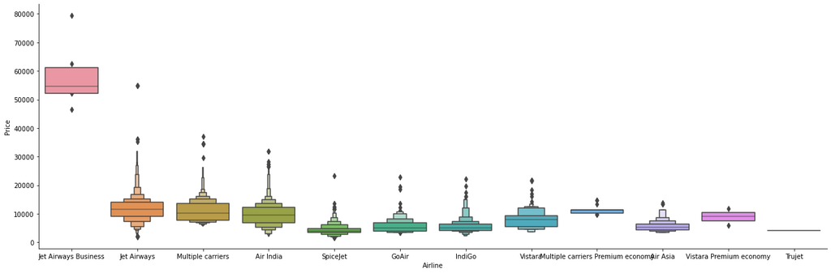

```python
import matplotlib.pyplot as plt
import seaborn as sns
# Airline vs price
sns.catplot(y= "Price", x = "Airline", data = train_df.sort_values("Price", ascending = False), kind="boxen", height = 6, aspect = 3)
plt.show()
```

From the grap we can say that jet Airways Business as the maximum price

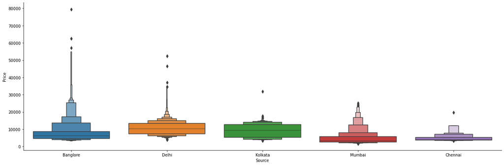

```python
# Compare Source and Price
sns.catplot(y = "Price", x= "Source", data = train_df.sort_values("Price", ascending = False), kind="boxen", height = 6, aspect = 3)
```

From the graph we can say that banglore as the maximum price

```python
# changing the categorical value to numerical value by labelencoder tecnique
from sklearn import preprocessing
le=preprocessing.LabelEncoder()
train_df['Airline']=le.fit_transform(train_df['Airline'])
train_df['Source']=le.fit_transform(train_df['Source'])
train_df['Destination']=le.fit_transform(train_df['Destination'])
train_df['Dep_Time']=le.fit_transform(train_df['Dep_Time'])
train_df['Total_Stops']=le.fit_transform(train_df['Total_Stops'])
train_df['Route']=le.fit_transform(train_df['Route'])
train_df['Additional_Info']=le.fit_transform(train_df['Additional_Info'])
train_df
```

|  | Airline | Source | Destination | Route | Dep_Time | Total_Stops | Additional_Info | Price | Journey_date | Journey_month | Arrival_hour | Arrival_minute | Duration_hours | Duration_mins |
| --- | --- | --- | --- | --- | --- | --- | --- | --- | --- | --- | --- | --- | --- | --- |
| 0 | 3 | 0 | 5 | 18 | 211 | 4 | 8 | 3897 | 24 | 3 | 1 | 10 | 2 | 50 |
| 1 | 1 | 3 | 0 | 84 | 31 | 1 | 8 | 7662 | 1 | 5 | 13 | 15 | 7 | 25 |
| 2 | 4 | 2 | 1 | 118 | 70 | 1 | 8 | 13882 | 9 | 6 | 4 | 25 | 19 | 0 |
| 3 | 3 | 3 | 0 | 91 | 164 | 0 | 8 | 6218 | 12 | 5 | 23 | 30 | 5 | 25 |
| 4 | 3 | 0 | 5 | 29 | 149 | 0 | 8 | 13302 | 1 | 3 | 21 | 35 | 4 | 45 |
| ... | ... | ... | ... | ... | ... | ... | ... | ... | ... | ... | ... | ... | ... | ... |
| 10678 | 0 | 3 | 0 | 64 | 183 | 4 | 8 | 4107 | 9 | 4 | 22 | 25 | 2 | 30 |
| 10679 | 1 | 3 | 0 | 64 | 193 | 4 | 8 | 4145 | 27 | 4 | 23 | 20 | 2 | 35 |
| 10680 | 4 | 0 | 2 | 18 | 58 | 4 | 8 | 7229 | 27 | 4 | 11 | 20 | 3 | 0 |
| 10681 | 10 | 0 | 5 | 18 | 92 | 4 | 8 | 12648 | 1 | 3 | 14 | 10 | 2 | 40 |
| 10682 | 1 | 2 | 1 | 108 | 85 | 1 | 8 | 11753 | 9 | 5 | 19 | 15 | 8 | 20 |

10682 rows × 14 columns

```python
# checking for skewness in the train_df dataset
train_df.skew()
```

```
Airline            0.731057
Source            -0.424023
Destination        1.244046
Route             -0.501911
Dep_Time           0.194914
Total_Stops        0.631532
Additional_Info   -1.779689
Price              1.812405
Journey_date       0.118174
Journey_month     -0.387409
Arrival_hour      -0.370146
Arrival_minute     0.110945
Duration_hours     0.851197
Duration_mins     -0.090680
dtype: float64
```

```python
# checking for co relation
train_df.corr()
```

|  | Airline | Source | Destination | Route | Dep_Time | Total_Stops | Additional_Info | Price | Journey_date | Journey_month | Arrival_hour | Arrival_minute | Duration_hours | Duration_mins |
| --- | --- | --- | --- | --- | --- | --- | --- | --- | --- | --- | --- | --- | --- | --- |
| Airline | 1.000000 | -0.013397 | 0.018446 | 0.025214 | -0.039508 | 0.035973 | -0.060748 | -0.039565 | 0.026137 | 0.024674 | -0.007567 | -0.071092 | -0.158136 | -0.028009 |
| Source | -0.013397 | 1.000000 | -0.592576 | 0.403412 | 0.055194 | -0.225605 | -0.022109 | 0.015999 | 0.004902 | 0.183268 | 0.025635 | 0.021040 | 0.166121 | -0.145193 |
| Destination | 0.018446 | -0.592576 | 1.000000 | -0.461176 | -0.063625 | 0.337872 | 0.026821 | -0.071122 | -0.041025 | -0.364682 | -0.039729 | 0.017196 | -0.258446 | 0.061235 |
| Route | 0.025214 | 0.403412 | -0.461176 | 1.000000 | -0.082013 | -0.437749 | 0.035152 | 0.164149 | 0.081632 | 0.244186 | 0.013898 | -0.173352 | 0.295444 | -0.232427 |
| Dep_Time | -0.039508 | 0.055194 | -0.063625 | -0.082013 | 1.000000 | 0.044647 | -0.052828 | 0.002931 | 0.001450 | 0.034610 | 0.000015 | 0.066656 | -0.001247 | -0.016261 |
| Total_Stops | 0.035973 | -0.225605 | 0.337872 | -0.437749 | 0.044647 | 1.000000 | 0.164054 | -0.571221 | 0.029225 | -0.026328 | -0.095650 | 0.175980 | -0.606137 | 0.182223 |
| Additional_Info | -0.060748 | -0.022109 | 0.026821 | 0.035152 | -0.052828 | 0.164054 | 1.000000 | -0.065463 | -0.016296 | -0.051491 | 0.026204 | 0.041310 | -0.168815 | 0.046910 |
| Price | -0.039565 | 0.015999 | -0.071122 | 0.164149 | 0.002931 | -0.571221 | -0.065463 | 1.000000 | -0.153774 | -0.103643 | 0.024244 | -0.086155 | 0.508778 | -0.124855 |
| Journey_date | 0.026137 | 0.004902 | -0.041025 | 0.081632 | 0.001450 | 0.029225 | -0.016296 | -0.153774 | 1.000000 | -0.038359 | -0.003245 | -0.017510 | -0.022059 | -0.008940 |
| Journey_month | 0.024674 | 0.183268 | -0.364682 | 0.244186 | 0.034610 | -0.026328 | -0.051491 | -0.103643 | -0.038359 | 1.000000 | -0.003927 | -0.100626 | 0.016141 | -0.040897 |
| Arrival_hour | -0.007567 | 0.025635 | -0.039729 | 0.013898 | 0.000015 | -0.095650 | 0.026204 | 0.024244 | -0.003245 | -0.003927 | 1.000000 | -0.154363 | 0.055276 | -0.118309 |
| Arrival_minute | -0.071092 | 0.021040 | 0.017196 | -0.173352 | 0.066656 | 0.175980 | 0.041310 | -0.086155 | -0.017510 | -0.100626 | -0.154363 | 1.000000 | -0.074450 | 0.151628 |
| Duration_hours | -0.158136 | 0.166121 | -0.258446 | 0.295444 | -0.001247 | -0.606137 | -0.168815 | 0.508778 | -0.022059 | 0.016141 | 0.055276 | -0.074450 | 1.000000 | -0.126468 |
| Duration_mins | -0.028009 | -0.145193 | 0.061235 | -0.232427 | -0.016261 | 0.182223 | 0.046910 | -0.124855 | -0.008940 | -0.040897 | -0.118309 | 0.151628 | -0.126468 | 1.000000 |

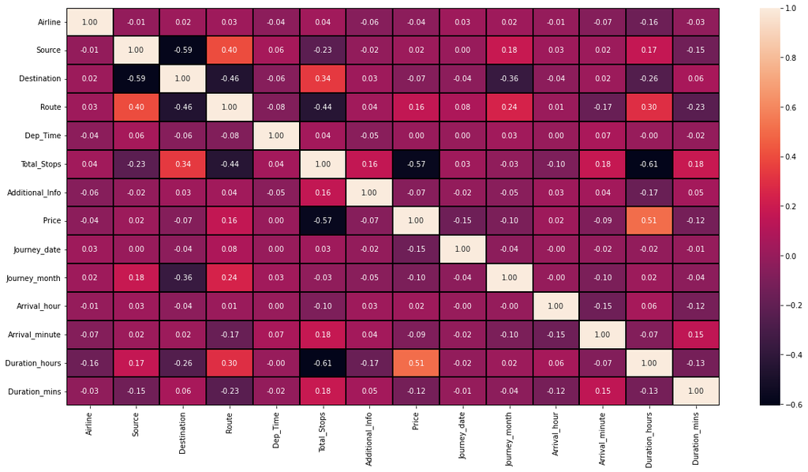

```python
#Reprasantation of co relation values by using the heatmap
import matplotlib.pyplot as plt
plt.figure(figsize=(20,10))
sns.heatmap(train_df.corr(),annot=True,linewidth=0.1,linecolor='black',fmt='0.2f')
```